# Adaptive Policy: Tax

Ernesto

October 3, 2016

## Simple Policy-Making

This demo is the first attempt to include some form of policy-making in the model. So far we have been optimizing policy and regulations from the outside but real rules are set in response to measurements rather than fixed for 20 years at the very start of the fishery.  
The policy-making here is very simple and straightforward but it proves nicely the kind of work we can do.

## Switching gear

Let me start with a simple example taken from the draft appendix: gear change. There are 2 species of fish, red and blue, well-mixed throughout the sea. Each species of fish sells for 10$/kg. There are 2 kinds of gear: gear that catches only blue or only red. There are 150 fishers who can switch gear every two months (always by explore-exploit-imitate).

The key result in the draft is that, even without knowing anything about the actual biomass numbers, an equilibrium emerges where both blue and red fish get landed at about the same rate.

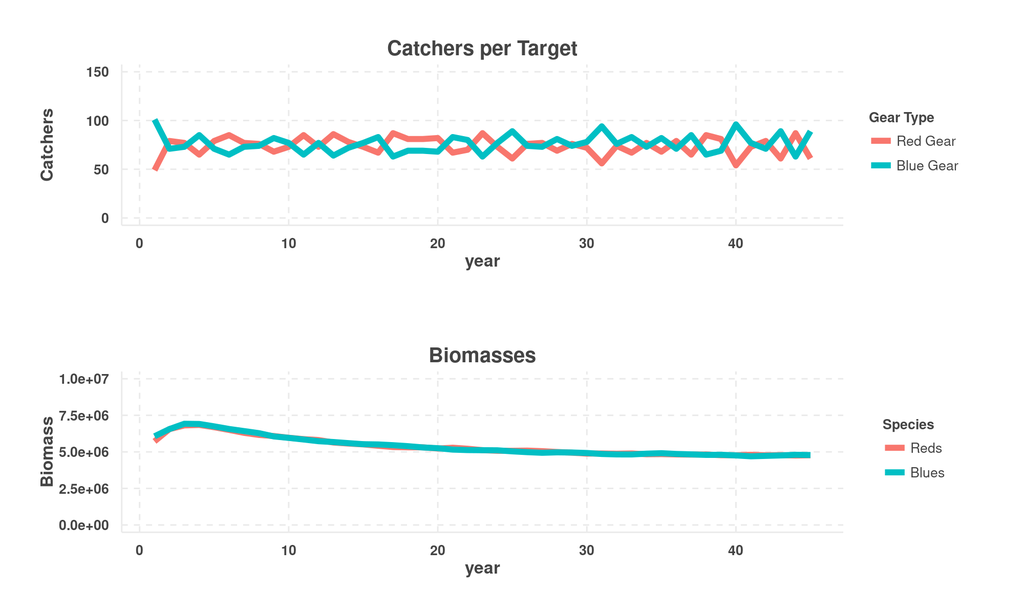

Now imagine that we increase the price of blue fish to 30$/kg. With no policy agents mostly target blue, switching for a few years to red catches when depletion makes targeting blue just too expensive.

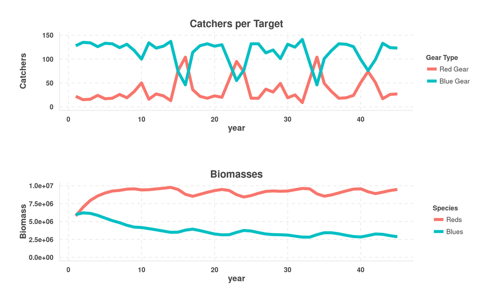

## Simple Policy-making

Imagine that we have a simple one-liner policy-making:

```r
if biomass < threshold
   tax=t
```

There is a minimum level of biomass equal to `threshold` below which we impose a tax equal to `t`. The policy-maker checks biomass (perfectly) once a year. Not a particularly subtle policy but a quick way to test the model.

If we set a 100% tax on blue fish whenever its biomass is below 5 million kg you obviously get a very hard lower bound:

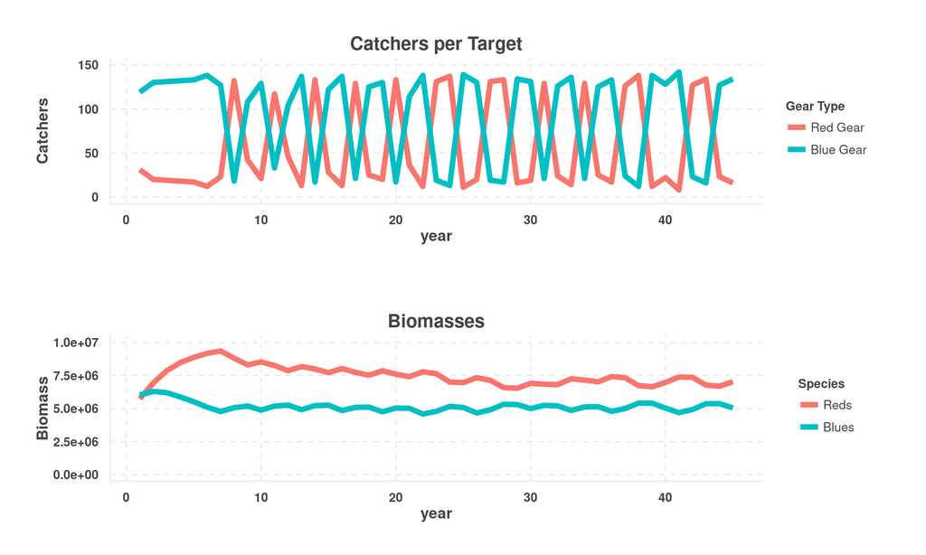

Notice the bouncing around the 5 million mark: that’s a consequence of the policy strategy using a single threshold rather than smoother boundaries.

Obviously policy-making is governed by parameters and we can optimize those just like any other policy. If we take as objective to maximize pre-tax revenues, that is:
$$\text{Score} = 10 \times \text{Red Landings} + 30 \times \text{Blue Landings}$$
and we are looking to put a tax on blue fish (the expensive one) then the dynamics we generate are:

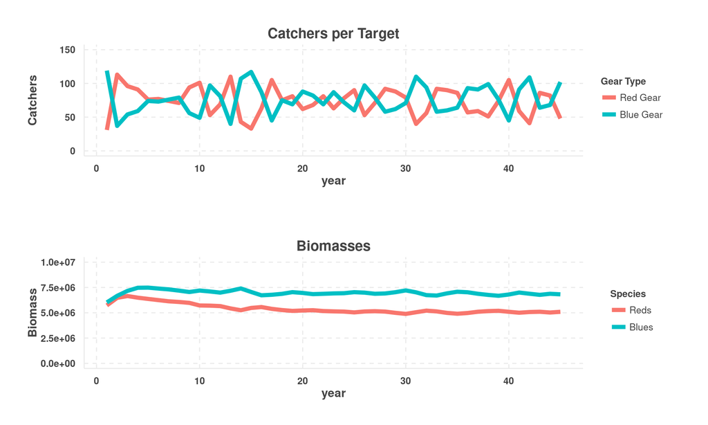

Which is obtained by putting a tax of 22.84$/kg with a high threshold of 8 million (which means, a constant tax). This makes red fish more profitable for fishers which is why you red biomass drops faster. But it also incentivates the conservation of the more valuable blue fish.

The tax is socially optimal in the sense that it increases (by about a eight) the total revenues from fisheries. It is not Pareto efficient however as fishermen are worse off (since the government through the tax collects a large portion of the revenues):

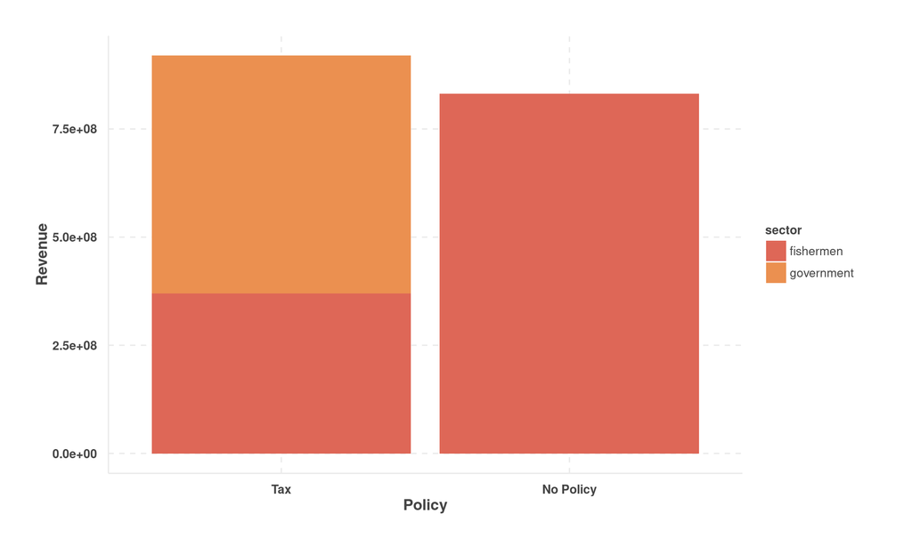